# 11. Place names and data

Communications adjusts place names and other text associated with places. This information is stored in the Places_Neue table in FileMaker.

# Import adjustments

The “newsignup” program imports the places data from the Enterprise Database export from Hastus and then makes some minor modifications before it’s saved to be imported into FileMaker.

The import adjustment routine is in the sub “hastus_place_import” in the module “Octium::Import::CalculateFields”. It does two important[^1] modifications:

- It makes the timepoint name into title case (field i_description). This is not important now because Planning changed the descriptions to be all title case, and in fact incorporated most of my overridden place names into Hastus wholesale. (Thanks!) But they used to be in all caps.
- It creates a default city name (field i_city), based on the “district” encoded in Hastus (1 = Alameda, 2 = Albany, 3.= Berkeley, etc., down to 99 = Contra Costa County).

# Default / override / final

Several of the fields work this way: there’s a default, provided by either the Hastus export or an automatic adjustment of the Hastus export. The user then has the opportunity to override that by entering data into an override field. A third field, a calculated field (I think these are called “computed fields” in some database systems), holds whatever the final result is – the default, or the overridden value if there is one. If the override value is just a period, the result will be empty.

# Field name convention

Fields beginning:

h_ come from the Hastus export without modification

i_ are adjustments to the Hastus export made by the newsignup

o_ are fields that allow overriding either an h_ or i_ field

c_ are calculated fields, including a bunch of “if there’s an o_ entry, use it, otherwise use the default” fields.

u_ are fields entered from scratch by the FileMaker user

If it has an “x” in the header, this means that this isn’t used now.[^2]

# Communications contributed data

Communications contributes three main pieces of data that are still used.

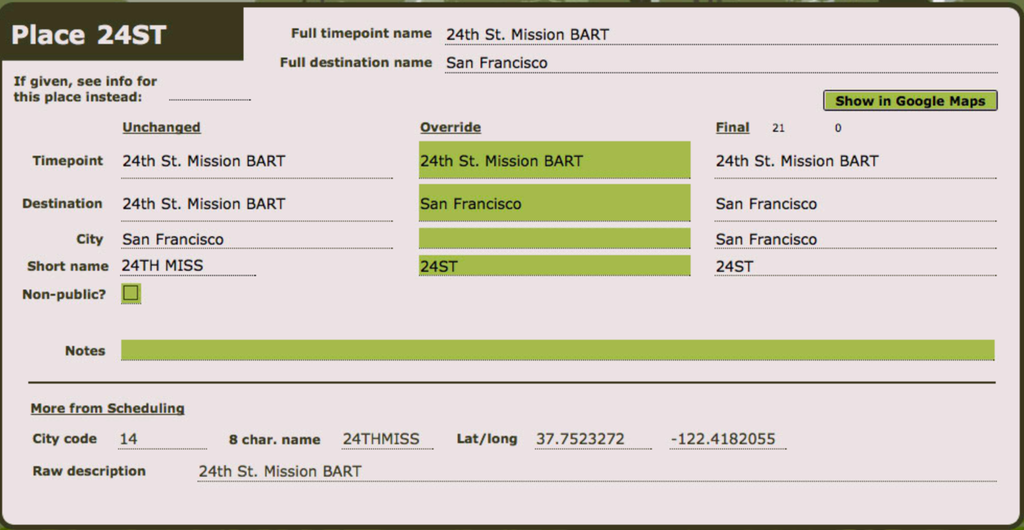

- Override timepoint description (o_description, c_description). I think that since all the descriptions from this system were copied into Hastus, that now this would be considered unnecessary. In any event, this is probably unnecessary now, and that all timepoint descriptions should be entered in Hastus and used without adjustment.
- Override timepoint destination. Unlike most of the overrides, this actually uses the c_description field as the default rather than some piece of data from Hastus. Many destination names are exactly the same as the timepoint name, but some timepoint descriptions are not ideal as destination names, such as “To Salesforce Transit Center” instead of “San Francisco” for transbay buses.
- Override city. The main use for this is where I want to use census designated places rather than legal jurisdictions, because people think of places as being in in San Lorenzo or Castro Valley rather than the generic “Alameda County.”

To my recollection, the other fields here are now vestigial.[^3]

# Issues and Future

As well as being used in the at-stop schedules and the (now unused) flag specification system, the “c_destination” field in this database is the source for all the direction and pattern destinations used in BusTime. (The program actium.pl avl2patdest gets the destination associated with the last timepoint on each pattern and puts it in the appropriate files.)

It usually works okay, but there are a few cases where some destination names work better for some lines than others. The last timepoint for both the SB line from San Francisco to Newark, and a number of the 600-series lines serving Newark Memorial High School, was “CEST”, Cedar Blvd. & Stevenson Blvd. For the SB, the best destination would have been just “Newark,” but the city name alone isn’t helpful for those 600-series lines. If I could have, I would have established a new system that specified the destination for each line and pattern directly, as part of the flag system.

Barring that, there are a few cases where what’s on the headsign and the destination used here don’t relate to each other. These should be made consistent. Since I wrote these destinations I naturally think it’s the headsigns that should be changed, but someone else might disagree.

[^1]: The third modification is this: there is a field in Hastus that consists of the eight-character timepoint names used in Hastus schedule reports and, I think, paddles – for example, the name for the place whose ID is “24ST” is “24THMISS”. It has the very misleading name of “plc_number”. The import routine creates an additional field called “i_abbrev9” that adds a space between the fourth and fifth characters. For the first 10+ years of my work, this was used as the timepoint identifier, because originally all I got from Scheduling was the schedule reports. I *think* all references to this have, after many years, been removed the code, so this is now vestigial – but I may have forgotten something.
[^2]: At one point I decided that some place descriptions or destinations that weren’t specific enough, such as street intersections, should have a city name in some uses of the description. That is, we would use “Bret Harte Middle School, Hayward” rather than just “Bret Harte Middle School,” since there are two of those in the district, but we wouldn’t need to add the city for BART stations or things with the city in the name (“San Leandro Library”). These aren’t used now but I wonder sometimes if I should have kept using them, at least sometimes.
[^3]: It would have been nice if I’d implemented “Non-public” so the xhea2sked would know that “OARC” on lines 805 and 21, and “D4” on Line 19, shouldn’t be included. As it is, those have to be removed using a manual exception.